## Chapter 7: Linear multi-class classification

# 7.2 One-versus-All multi-class classification

You can toggle the code on and off in this presentation via the button below.

```python
from IPython.display import HTML

HTML('''<script>
code_show=true;
function code_toggle() {
 if (code_show){
 $('div.input').hide();
 } else {
 $('div.input').show();
 }
 code_show = !code_show
}
$( document ).ready(code_toggle);
</script>
<form action="javascript:code_toggle()"><input type="submit" value="Click here to toggle on/off the raw code."></form>''')
```

Many classification problems have more than two classes:

- face recognition
- hand gesture recognition
- general object detection
- speech recognition
- ...

Having just two sides, a single linear separator is fundamentally insufficient as a mechanism for differentiating between more than two classes of data.

Here we will see how to overcome this shortcoming when dealing with $C>2$ classes by learning $C$ linear classifiers (one per class), each distinguishing one class from the rest of the data.

This basic scheme is called **One-versus-All** multi-class classification.

## 7.2.1 Notation and modeling

A multiclass dataset $\left\{ \left(\mathbf{x}_{p,}\,y_{p}\right)\right\} _{p=1}^{P}$ consists of $C$ distinct classes of data.

Although we can in theory use *any $C$ distinct labels* to distinguish between the classes, it is convenient to use label values $y_{p}\in\left\{ 0,1,...,C-1\right\}$.

A prototypical toy $C = 3$ class dataset.

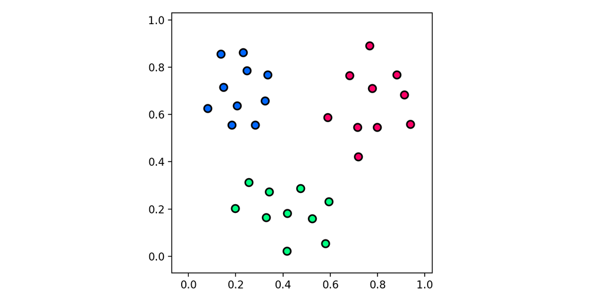

```python
# This code cell will not be shown in the HTML version of this notebook
# load in dataset
data = np.loadtxt(datapath + '3class_data.csv',delimiter = ',')

# create an instance of the ova demo
demo1 = superlearn.ova_illustrator.Visualizer(data)

# visualize dataset
demo1.show_dataset()
```

## 7.2.2 Training $C$ One-versus-All classifiers

**The goal:**

We want to learn how to distinguish each class of our data from the other $C-1$ classes.

**One solution:**

Learn $C$ two-class classifiers on the entire dataset (with the $c^{th}$ classifier trained to distinguish the $c^{th}$ class from the remainder of the data).

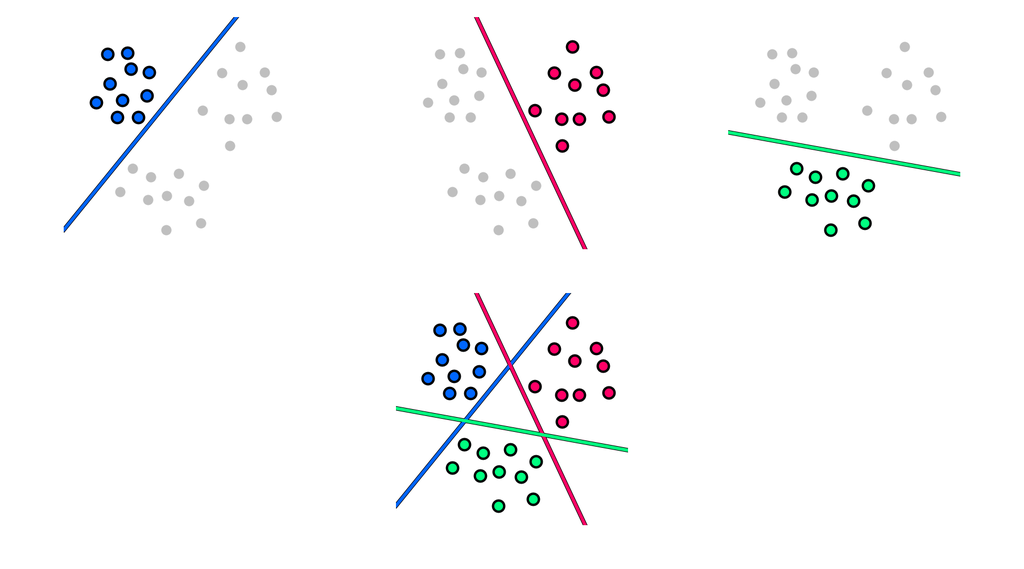

```python
# This code cell will not be shown in the HTML version of this notebook
# solve the 2-class subproblems
demo1.solve_2class_subproblems()

# illustrate dataset with each subproblem and learned decision boundary
demo1.plot_data_and_subproblem_separators()
```

The three places a point in the space can end up (w.r.t our classifiers):

**1. On the positive side of a single classifier**

**2. On the positive side of more than one classifier**

**3. On the negative side of all classifiers**

## 7.2.3 Points on the positive side of a single classifier

Denoting the weights from the $c^{th}$ classifier as $\mathbf{w}_c$

\begin{equation} \mathbf{w}_c=\begin{bmatrix} w_{0,c}\\ w_{1,c}\\ w_{2,c}\\ \vdots\\ w_{N,c} \end{bmatrix} \end{equation}

then the corresponding decision boundary can be written as

\begin{equation} \mathring{\mathbf{x}}_{\,}^T \mathbf{w}_c = 0. \end{equation}

The points that lie solely on the positive side of the $j^{th}$ classifier only should clearly belong to the $j^{th}$ class.

They clearly satisfy the condition \begin{equation} \mathring{\mathbf{x}}_{\,}^T \mathbf{w}_j = \underset{c \,=\, 0,...,C-1}{\text{max}} \,\,\,\mathring{\mathbf{x}}_{\,}^T \mathbf{w}_c \end{equation}

Therefore to get the associated label $y$ for these points, we can write \begin{equation} y = \underset{c \,=\, 0,...,C-1}{\text{argmax}} \,\,\,\mathring{\mathbf{x}}_{\,}^T \mathbf{w}_c \end{equation}

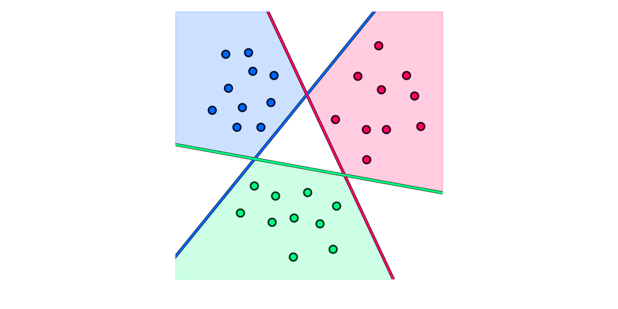

```python
# This code cell will not be shown in the HTML version of this notebook
# color those points clearly belonging to each individual class - those lying near the points we already have on the positive side of only one classifier.
demo1.show_fusion(region = 1)
```

## 7.2.4 Points on the positive side of more than one classifier

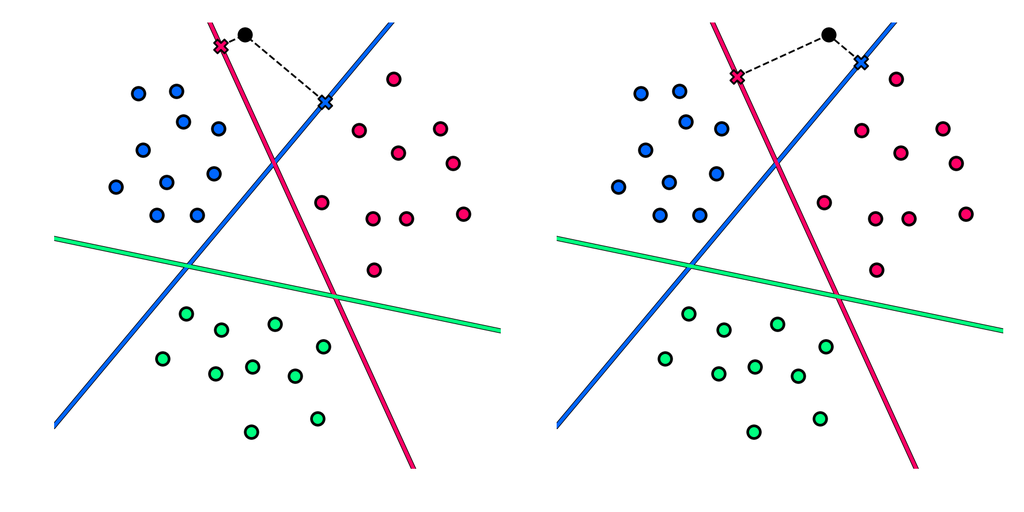

```python
# This code cell will not be shown in the HTML version of this notebook
# try examining a point and its distance to relevant decision boundaries
demo1.point_and_projection(point1 = [0.4,1] ,point2 = [0.6,1])
```

Which class should we assign each point to?

- Hint: we can think of a classifier as being 'more confident' of the class identity of given a point, the *farther* the point lies from the classifier's decision boundary (these points are more resistant to perturbations).

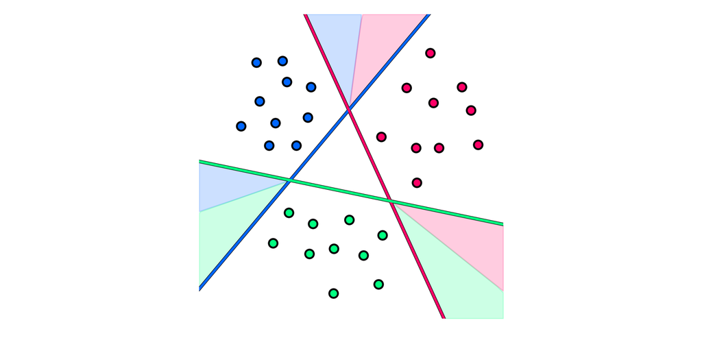

```python
# This code cell will not be shown in the HTML version of this notebook
# color points belonging on the positive side of two or more classifiers
demo1.show_fusion(region = 2)
```

**Classification rule:** in these regions we have assigned each point to the class whose boundary is at the largest nonnegative distance from it.

How do we compute the distance of an arbitrary point to each of our decision boundaries?

As discussed in [Section 6.3](https://jermwatt.github.io/machine_learning_refined/notes/6_Linear_twoclass_classification/6_3_Softmax.html), the *signed distance* of an arbitrary point $\mathbf{x}$ to the $j^{th}$ linear decision boundary is equal to the evaluation at this boundary *provided we normalize its parameters by the magnitude of its feature-touching weights*

\begin{equation} \text{signed distance of $\mathbf{x}$ to $j^{th}$ boundary} = \frac{\mathring{\mathbf{x}}_{\,}^T \mathbf{w}_j }{\left\Vert \boldsymbol{\omega}_{j}^{\,} \right\Vert_2} \end{equation}

where

\begin{equation} \text{(bias):}\,\, b_j = w_{0,j} \,\,\,\,\,\,\,\, \text{(feature-touching weights):} \,\,\,\,\,\, \boldsymbol{\omega}_j = \begin{bmatrix} w_{1,j} \\ w_{2,j} \\ \vdots \\ w_{N,j} \end{bmatrix}. \end{equation}

If we *normalize* the weights of each linear classifier by the length of its normal vector as

\begin{equation} \mathbf{w}_{j}^{\,} \longleftarrow \frac{\mathbf{w}_{j}^{\,}}{\left\Vert \boldsymbol{\omega}_{j}^{\,} \right\Vert_2} \end{equation}

then this distance is simply written as the raw evaluation of the point via the decision boundary as

\begin{equation} \text{signed distance of $\mathbf{x}$ to $j^{th}$ boundary} = \mathring{\mathbf{x}}_{\,}^T \mathbf{w}_j \end{equation}

Therefore again - after weight-normalization - we have precisely the same prediction rule we found originally for regions of the space where only a single classifier is positive

\begin{equation} y = \underset{c \,=\, 0,...,C-1}{\text{argmax}} \,\,\,\mathring{\mathbf{x}}_{\,}^T \mathbf{w}_c. \end{equation}

## 7.2.5 Points on the negative side of all classifiers

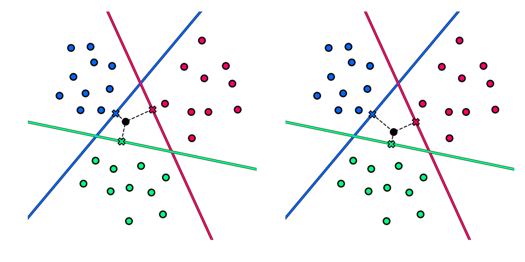

```python
# This code cell will not be shown in the HTML version of this notebook
# try examining a point and its distance to relevant decision boundaries
demo1.point_and_projection(point1 = [0.4,0.5] ,point2 = [0.45,0.45])
```

In this case we cannot argue that one classifier is more 'confident' in the class identity of such points. However, we can ask which classifier is the least 'unsure' about the class identity of such points?

Answer: **Not** the boundary it is **farthest** from (as was the case previously) but the one it is **closest** to.

If we repeat this logic for every point in the region ...

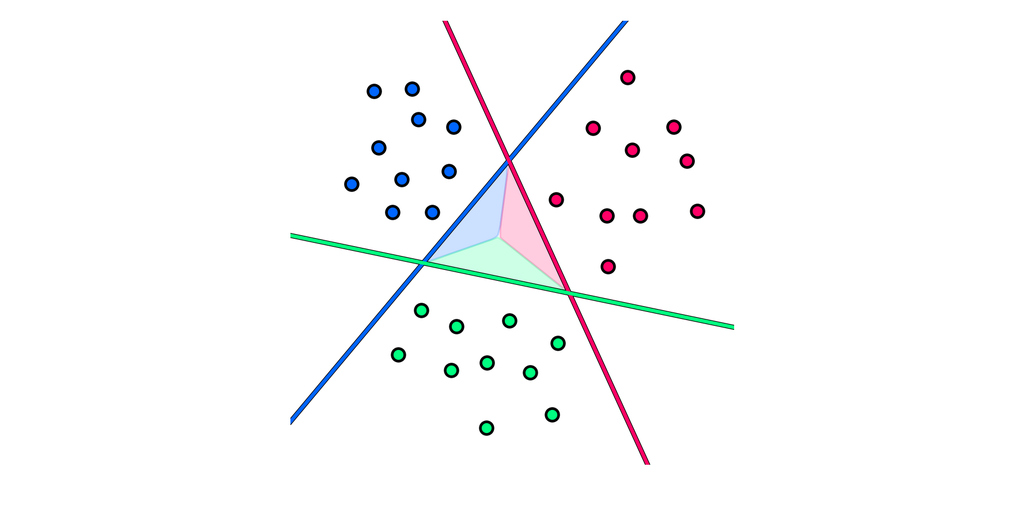

```python
# This code cell will not be shown in the HTML version of this notebook
# color the region on which all classifiers are negative
demo1.show_fusion(region = 3);
```

**Classification rule:** we assign a point to the class whose boundary is at the largest signed distance from it.

Expressed algebraically, once again we have

\begin{equation} y = \underset{c \,=\, 0,...,C-1}{\text{argmax}} \,\,\,\mathring{\mathbf{x}}_{\,}^T \mathbf{w}_c. \end{equation}

## 7.2.6 Putting it all together

We have now deduced that the single rule for assigning a label $y$ to a point $\mathbf{x}$

\begin{equation} y = \underset{c \,=\, 0,...,C-1}{\text{argmax}} \,\,\,\mathring{\mathbf{x}}_{\,}^T \mathbf{w}_c. \end{equation}

which assigns the label based on the maximum signed distance of this point to each classifier, applies to the entire space of our problem.

We call this the **fusion rule** since it tells us precisely how to fuse our $C$ individual classifiers together to make a unified and consistent classification across the entire space of any dataset.

### One-versus-All multi-class classification

**1:** **Input:** multiclass dataset $\left\{ \left(\mathbf{x}_{p,}\,y_{p}\right)\right\} _{p=1}^{P}$ where $y_{p}\in\left\{ 0,...,C-1\right\}$, two-class classification scheme and optimizer  
**2:** `for` $\,\,j \, = \, 0,...,C-1$  
**3:** form temporary labels $\tilde y_p = \begin{cases} +1 \,\,\,\,\,\,\text{if}\,\, y_p = j \\ -1 \,\,\,\,\,\,\text{if}\,\, y_p \neq j \end{cases}$  
**4:** solve two-class subproblem on $\left\{ \left(\mathbf{x}_{p,}\,\tilde y_{p}\right)\right\} _{p=1}^{P}$ to find weights $\mathbf{w}_j$  
**5:** normalize classifier weights by magnitude of feature-touching portion $\mathbf{w}_{j}^{\,} \longleftarrow \frac{\mathbf{w}_{j}^{\,} }{\left\Vert \boldsymbol{\omega}_{j}^{\,} \right\Vert_2}$  
**6:** `end for`  
**7:** To assign label $y$ to a point $\mathbf{x}$, apply the fusion rule: $y = \underset{c\,=\, 0,...,C-1}{\text{argmax}} \,\,\,\mathring{\mathbf{x}}_{\,}^T \mathbf{w}_c$

**Note:** In practice it is common to see implementations that skip the normalization in step 5. This can theoretically lead to poor classification due to different sized normal vectors creating out of scale distance-to-classifier measurements. However because often each classifier is trained using the same optimization framework (e.g., the same sized initialization and optimization algorithm) the resulting size of each trained normal vector can end up being around the same size (hence reducing the need for normalization).

### Multiclass decision boundary

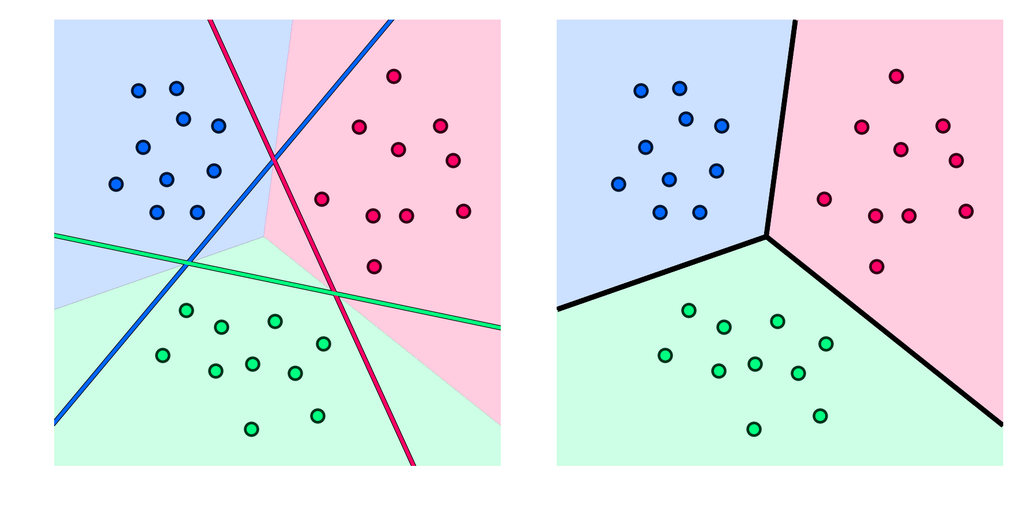

```python
# This code cell will not be shown in the HTML version of this notebook
# classify and color the entire space using our individual classifiers and the fusion rule
demo1.show_complete_coloring();
```

- The multi-class boundary (in black) arises at points where the fusion rule does not provide a unique solution
- The boundary resulting from the fusion rule is always piecewise-linear.
- While the fusion rule explicitly defines this boundary it does not provide us with a closed form formula for it as with e.g., logistic regression.

## 7.2.7 Implementing a One-versus-All classifier in `Python`

To take advantage of the `numpy` libraries fast array operations we use the notation first introduced in [Section 5.6](https://jermwatt.github.io/machine_learning_refined/notes/5_Linear_regression/5_6_Multi.html), we stack the trained weights from our $C$ classifiers together into a single $\left(N + 1\right) \times C$ array of the form

\begin{equation} \mathbf{W}=\begin{bmatrix} w_{0,0} & w_{0,1} & w_{0,2} & \cdots & w_{0,C-1} \\ w_{1,0} & w_{1,1} & w_{1,2} & \cdots & w_{1,C-1} \\ w_{2,0} & w_{2,1} & w_{2,2} & \cdots & w_{2,C-1} \\ \,\,\, {\vdots}_{\,\,\,} & {\vdots}_{\,\,\,} & {\vdots}_{\,\,\,} & \cdots & {\vdots}_{\,\,\,} \\ w_{N,0} & w_{N,1} & w_{N,2} & \cdots & w_{N,C-1} \\ \end{bmatrix} \end{equation}

We also extend our `model` notation to denote the evaluation of our $C$ individual linear models as

\begin{equation} \begin{matrix} \text{model}\left(\mathbf{x},\mathbf{W}\right) = \mathring{\mathbf{x}}_{\,}^T\mathbf{W} \end{matrix} = \begin{bmatrix} \mathring{\mathbf{x}}_{\,}^T \overset{\,}{\mathbf{w}}_{0}^{\,} & \mathring{\mathbf{x}}_{\,}^T \overset{\,}{\mathbf{w}}_{1}^{\,} & \cdots \, & \mathring{\mathbf{x}}_{\,}^T \overset{\,}{\mathbf{w}}_{C-1}^{\,} \end{bmatrix} \end{equation}

#### Example 1: Classifying a dataset with $C = 4$ classes using OvA

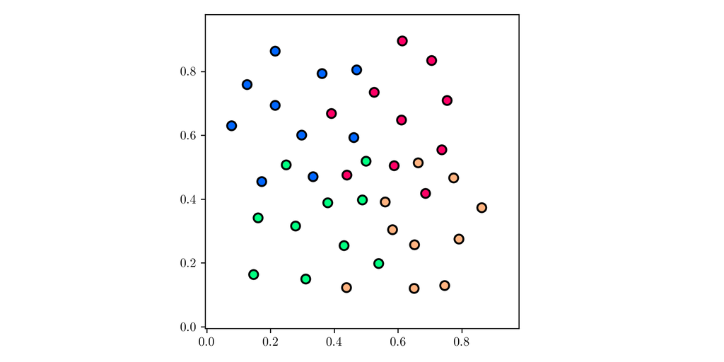

```python
# This code cell will not be shown in the HTML version of this notebook
# load in dataset
data3 = np.loadtxt(datapath + '4class_data.csv',delimiter = ',');

# create an instance of the ova demo
demo3 = superlearn.ova_illustrator.Visualizer(data3);

# visualize dataset
demo3.show_dataset();
```

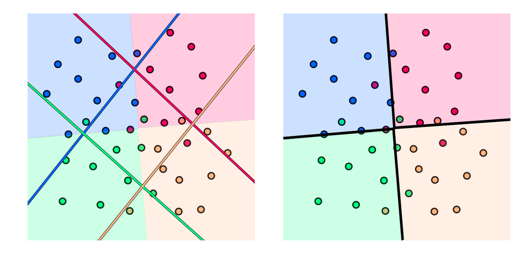

```python
# This code cell will not be shown in the HTML version of this notebook
# solve the 2-class subproblems
demo3.solve_2class_subproblems()

# classify and color the entire space using our individual classifiers and the fusion rule
demo3.show_complete_coloring()
```

Note with this dataset that each class is *not* linearly separable from the remainder of the data. This is no matter - the OvA framework still produces an appropriate multi-class boundary.

## 7.2.8 Interpreting the fusion rule as a discrete step function

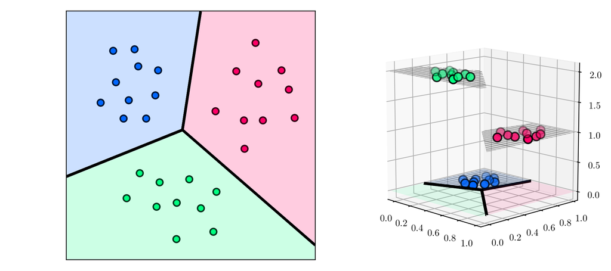

```python
# This code cell will not be shown in the HTML version of this notebook
# load in dataset
data = np.loadtxt(datapath + '3class_data.csv',delimiter = ',')

# get input/output pairs
x = data[:-1,:]
y = data[-1:,:]

# create an instance of the ova demo
demo = superlearn.multiclass_illustrator.Visualizer(data)

# load in OvA framework
ova = superlearn.one_versus_all

# run OvA on dataset
w = 0.1*np.random.randn(3,1); max_its = 10; optimizer = 'newtons_method'; epsilon = 10**(-7)
weight_history, count_history = ova.train(x,y,max_its = max_its,optimizer = optimizer,w = w,epsilon = epsilon)

# plot classification of space, individual learned classifiers (left panel) and joint boundary (middle panel), and cost-function panel in the right panel
demo.show_discrete_step(weight_history,view = [12,-44])
```